# 🏡 **Caso del Proyecto:** "Predicción del precio de viviendas en la ciudad de Medellín"

1. **Contexto del Proyecto**

La Alcaldía de Medellín, en conjunto con una fintech de créditos hipotecarios, está interesada en predecir de manera precisa el valor de mercado de propiedades residenciales. Esto con el fin de:

- Agilizar el proceso de aprobación de créditos.
- Identificar zonas de valorización o riesgo.
- Brindar herramientas de pricing automático para vendedores y compradores.
2. Objetivo General
- Desarrollar un modelo de machine learning capaz de predecir el precio de venta de una casa o apartamento en Medellín a partir de sus características.
3. Objetivos Específicos
- Recolectar y depurar un dataset de propiedades reales.
- Realizar análisis exploratorio de datos (EDA).
- Crear modelos de regresión (lineal, árbol de decisión, random forest, XGBoost, etc.) y comparar su rendimiento.
- Validar el modelo con métricas como RMSE, MAE y R².
- Implementar una herramienta simple de visualización o consulta (opcional).
4. Variables Posibles

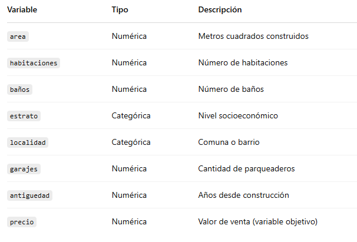

5. Resultados Esperados
- Reporte técnico con análisis exploratorio, modelos aplicados, validación de resultados.
- Visualizaciones claras sobre las variables que más influyen en el precio.
- Una recomendación final sobre el modelo óptimo para implementar.

## **Importar Data**

```python
from google.colab import files
uploaded = files.upload()
```

Upload widget is only available when the cell has been executed in the current browser session. Please rerun this cell to enable.

```
Saving Dataset_ficticio_de_precios_de_viviendas.csv to Dataset_ficticio_de_precios_de_viviendas.csv
```

```python
import pandas as pd

df = pd.read_csv("Dataset_ficticio_de_precios_de_viviendas.csv")

# Mostrar las primeras filas
df.head()
```

|  | area_m2 | habitaciones | baños | estrato | localidad | garajes | antiguedad | precio |
| --- | --- | --- | --- | --- | --- | --- | --- | --- |
| 0 | 104 | 3 | 3 | 3 | Laureles | 1 | 34 | 4285833 |
| 1 | 85 | 3 | 1 | 4 | San Javier | 1 | 46 | 1693251 |
| 2 | 109 | 3 | 3 | 4 | Doce de Octubre | 0 | 1 | 3843322 |
| 3 | 135 | 5 | 1 | 4 | Buenos Aires | 2 | 29 | 4126917 |
| 4 | 82 | 3 | 2 | 6 | Castilla | 1 | 33 | 1999996 |

```
Primeras filas del dataset:
```

|  | area_m2 | habitaciones | baños | estrato | localidad | garajes | antiguedad | precio |
| --- | --- | --- | --- | --- | --- | --- | --- | --- |
| 0 | 104 | 3 | 3 | 3 | Laureles | 1 | 34 | 4285833 |
| 1 | 85 | 3 | 1 | 4 | San Javier | 1 | 46 | 1693251 |
| 2 | 109 | 3 | 3 | 4 | Doce de Octubre | 0 | 1 | 3843322 |
| 3 | 135 | 5 | 1 | 4 | Buenos Aires | 2 | 29 | 4126917 |
| 4 | 82 | 3 | 2 | 6 | Castilla | 1 | 33 | 1999996 |

```
Resumen estadístico:
```

|  | area_m2 | habitaciones | baños | estrato | garajes | antiguedad | precio |
| --- | --- | --- | --- | --- | --- | --- | --- |
| count | 500.000000 | 500.000000 | 500.000000 | 500.000000 | 500.00000 | 500.00000 | 5.000000e+02 |
| mean | 89.836000 | 2.844000 | 1.894000 | 3.860000 | 0.93600 | 25.06000 | 3.181653e+06 |
| std | 29.043901 | 0.984684 | 0.695508 | 1.191318 | 0.70491 | 14.90304 | 1.554956e+06 |
| min | 30.000000 | 1.000000 | 1.000000 | 2.000000 | 0.00000 | 0.00000 | 6.992790e+05 |
| 25% | 68.750000 | 2.000000 | 1.000000 | 3.000000 | 0.00000 | 12.00000 | 2.052222e+06 |
| 50% | 90.000000 | 3.000000 | 2.000000 | 4.000000 | 1.00000 | 26.00000 | 2.899700e+06 |
| 75% | 109.000000 | 4.000000 | 2.000000 | 5.000000 | 1.00000 | 38.00000 | 3.975192e+06 |
| max | 205.000000 | 5.000000 | 3.000000 | 6.000000 | 2.00000 | 49.00000 | 1.069562e+07 |

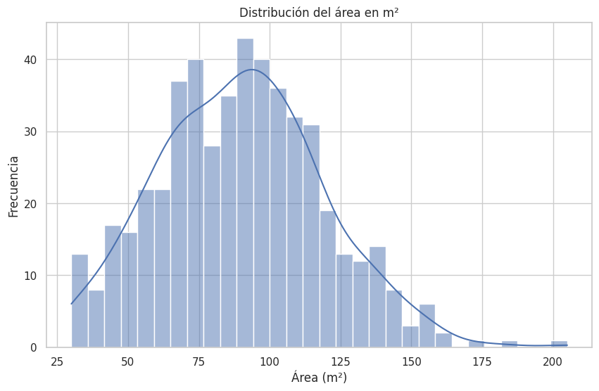

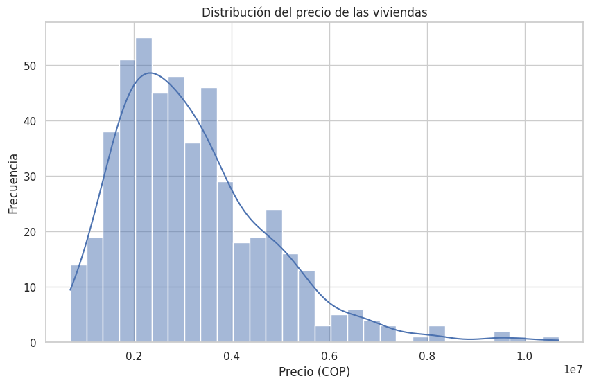

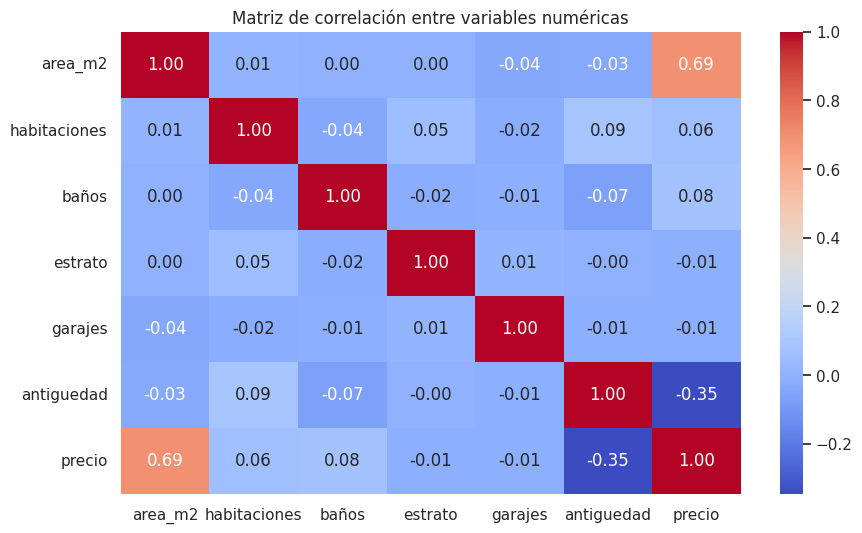

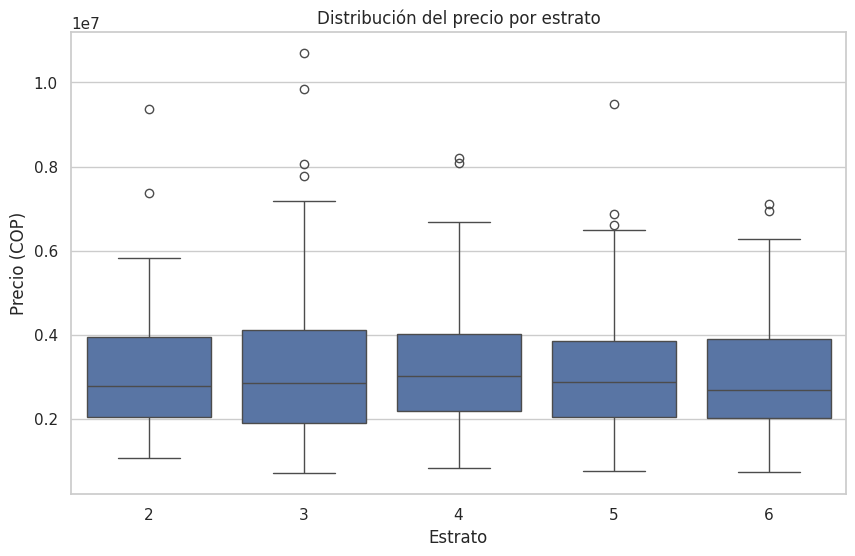

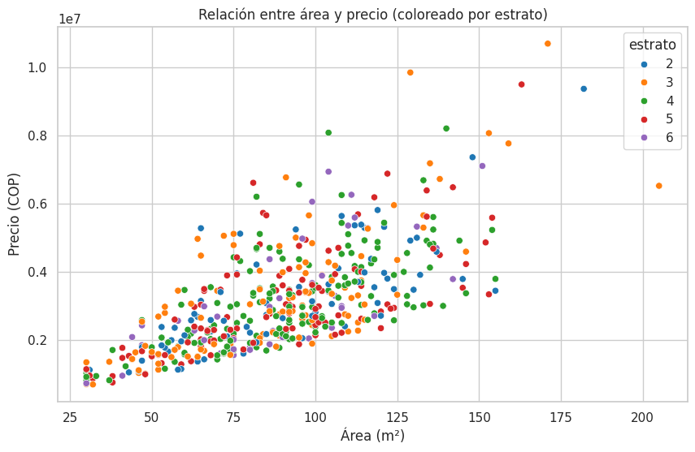

```python
import matplotlib.pyplot as plt
import seaborn as sns

# Configuraciones generales
plt.rcParams["figure.figsize"] = (10, 6)
sns.set(style="whitegrid")

# 1. Primeras filas
print("Primeras filas del dataset:")
display(df.head())

# 2. Resumen estadístico
print("\nResumen estadístico:")
display(df.describe())

# 3. Histograma del área
plt.figure()
sns.histplot(df["area_m2"], bins=30, kde=True)
plt.title("Distribución del área en m²")
plt.xlabel("Área (m²)")
plt.ylabel("Frecuencia")
plt.show()

# 4. Histograma del precio
plt.figure()
sns.histplot(df["precio"], bins=30, kde=True)
plt.title("Distribución del precio de las viviendas")
plt.xlabel("Precio (COP)")
plt.ylabel("Frecuencia")
plt.show()

# 5. Matriz de correlación
correlaciones = df.corr(numeric_only=True)
plt.figure()
sns.heatmap(correlaciones, annot=True, cmap="coolwarm", fmt=".2f")
plt.title("Matriz de correlación entre variables numéricas")
plt.show()

# 6. Boxplot del precio por estrato
plt.figure()
sns.boxplot(x="estrato", y="precio", data=df)
plt.title("Distribución del precio por estrato")
plt.xlabel("Estrato")
plt.ylabel("Precio (COP)")
plt.show()

# 7. Relación entre área y precio
plt.figure()
sns.scatterplot(x="area_m2", y="precio", hue="estrato", data=df, palette="tab10")
plt.title("Relación entre área y precio (coloreado por estrato)")
plt.xlabel("Área (m²)")
plt.ylabel("Precio (COP)")
plt.show()
```

**📊 Gráfica 1: Distribución del área en m²**

La mayoría de las viviendas tienen entre 60 y 120 m², con un valor promedio cercano a los 90 m².

**Conclusión:**

Hay una distribución normal del tamaño, lo que sugiere que la variable area_m2 es útil y estable para predecir el precio.

**📊 Gráfica 2: Distribución del precio de las viviendas**

Los precios están concentrados entre 1.5 y 5 millones de COP, pero hay valores altos que podrían considerarse outliers (por encima de 8 millones).

**Conclusión:**

El precio no se distribuye normalmente, lo que indica que podría necesitar una transformación (como logaritmo) para mejorar algunos modelos predictivos.

**📊 Gráfica 3: Matriz de correlación**

**Conclusión:**

Área y antigüedad son las variables más predictivas para el precio. El resto puede ser más útil en combinación.

**📊 Gráfica 4: Boxplot del precio por estrato**

**📊 Gráfica 5: Scatter plot de área vs precio (coloreado por estrato)**

Existe una relación lineal clara: a mayor área, mayor precio. Además, dentro de cada estrato hay una distribución coherente.

## Modelos predictivos

### Regresión Lineal

```python
# 📌 1. Importar librerías necesarias
import pandas as pd
from sklearn.model_selection import train_test_split
from sklearn.linear_model import LinearRegression
from sklearn.metrics import mean_squared_error, mean_absolute_error, r2_score

# 📌 2. Cargar el archivo CSV (ya cargado previamente)
df = pd.read_csv("Dataset_ficticio_de_precios_de_viviendas.csv")

# 📌 3. Seleccionar variables predictoras y variable objetivo
X = df[["area_m2", "habitaciones", "baños", "estrato", "garajes", "antiguedad"]]
y = df["precio"]

# 📌 4. Dividir datos en entrenamiento (80%) y prueba (20%)
X_train, X_test, y_train, y_test = train_test_split(X, y, test_size=0.2, random_state=42)

# 📌 5. Crear y entrenar el modelo de regresión lineal
modelo_lr = LinearRegression()
modelo_lr.fit(X_train, y_train)

# 📌 6. Hacer predicciones
y_pred = modelo_lr.predict(X_test)

# 📌 7. Evaluar el modelo (corregido sin el argumento "squared")
mse = mean_squared_error(y_test, y_pred)
rmse = mse ** 0.5  # raíz cuadrada del MSE = RMSE
mae = mean_absolute_error(y_test, y_pred)
r2 = r2_score(y_test, y_pred)

# Calcular coeficientes del modelo
coeficientes = pd.DataFrame({
    "Variable": X.columns,
    "Coeficiente": modelo_lr.coef_
})

# Mostrar métricas de evaluación y coeficientes
print("📊 Evaluación del modelo:")
print(f"RMSE: ${rmse:,.0f} COP")
print(f"MAE: ${mae:,.0f} COP")
print(f"R²: {r2:.2f}")

print("\n🧠 Coeficientes del modelo:")
print(coeficientes)
```

```
📊 Evaluación del modelo:
RMSE: $923,013 COP
MAE: $766,837 COP
R²: 0.49

🧠 Coeficientes del modelo:
       Variable    Coeficiente
0       area_m2   37122.422399
1  habitaciones  131641.401289
2         baños  149102.427191
3       estrato  -14300.407115
4       garajes    4285.113749
5    antiguedad  -37149.024117
```

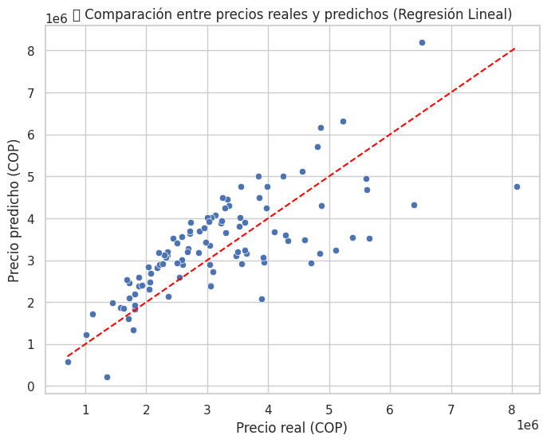

```python
import matplotlib.pyplot as plt
import seaborn as sns

# Crear gráfico de dispersión
plt.figure(figsize=(8,6))
sns.scatterplot(x=y_test, y=y_pred)
plt.plot([y_test.min(), y_test.max()], [y_test.min(), y_test.max()], color='red', linestyle='--')  # línea ideal
plt.xlabel("Precio real (COP)")
plt.ylabel("Precio predicho (COP)")
plt.title("📉 Comparación entre precios reales y predichos (Regresión Lineal)")
plt.grid(True)
plt.show()
```

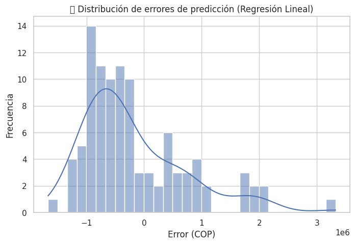

```python
# Calcular el error
errores = y_test - y_pred

# Histograma de errores
plt.figure(figsize=(8,5))
sns.histplot(errores, bins=30, kde=True)
plt.title("📊 Distribución de errores de predicción (Regresión Lineal)")
plt.xlabel("Error (COP)")
plt.ylabel("Frecuencia")
plt.grid(True)
plt.show()
```

### **Random Forest**

```python
# 📌 1. Importar el modelo y métricas
from sklearn.ensemble import RandomForestRegressor
from sklearn.metrics import mean_squared_error, mean_absolute_error, r2_score

# 📌 2. Crear y entrenar el modelo
modelo_rf = RandomForestRegressor(n_estimators=100, random_state=42)
modelo_rf.fit(X_train, y_train)

# 📌 3. Hacer predicciones
y_pred_rf = modelo_rf.predict(X_test)

# 📌 4. Evaluar el modelo
mse_rf = mean_squared_error(y_test, y_pred_rf)
rmse_rf = mse_rf ** 0.5
mae_rf = mean_absolute_error(y_test, y_pred_rf)
r2_rf = r2_score(y_test, y_pred_rf)

print("🌳 Evaluación del modelo Random Forest:")
print(f"RMSE: ${rmse_rf:,.0f} COP")
print(f"MAE: ${mae_rf:,.0f} COP")
print(f"R²: {r2_rf:.2f}")
```

```
🌳 Evaluación del modelo Random Forest:
RMSE: $1,110,037 COP
MAE: $843,811 COP
R²: 0.27
```

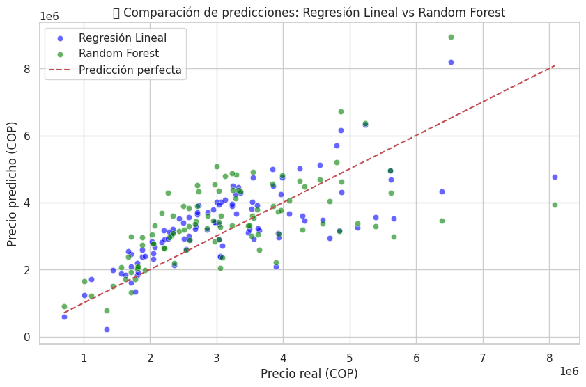

```python
plt.figure(figsize=(10, 6))

# Regresión lineal
sns.scatterplot(x=y_test, y=y_pred, label="Regresión Lineal", color="blue", alpha=0.6)

# Random Forest
sns.scatterplot(x=y_test, y=y_pred_rf, label="Random Forest", color="green", alpha=0.6)

# Línea ideal (predicción perfecta)
plt.plot([y_test.min(), y_test.max()], [y_test.min(), y_test.max()], 'r--', label="Predicción perfecta")

plt.xlabel("Precio real (COP)")
plt.ylabel("Precio predicho (COP)")
plt.title("📊 Comparación de predicciones: Regresión Lineal vs Random Forest")
plt.legend()
plt.grid(True)
plt.show()
```

```python
resultados = pd.DataFrame({
    "Modelo": ["Regresión Lineal", "Random Forest"],
    "RMSE": [rmse, rmse_rf],
    "MAE": [mae, mae_rf],
    "R²": [r2, r2_rf]
})

print("📋 Comparación de métricas:")
display(resultados)
```

```
📋 Comparación de métricas:
```

|  | Modelo | RMSE | MAE | R² |
| --- | --- | --- | --- | --- |
| 0 | Regresión Lineal | 9.230135e+05 | 766836.762269 | 0.492529 |
| 1 | Random Forest | 1.110037e+06 | 843811.061500 | 0.266043 |

## **Conclusión**

🧠 **Interpretación:**

🧩 **¿Por qué la Regresión Lineal fue mejor?**

- En este dataset, la relación entre las variables (área, habitaciones, baños, etc.) y el precio parece suficientemente lineal, lo que favorece al modelo lineal.
- La variable localidad, que podría ser crucial para un modelo más complejo como Random Forest, no fue incluida en formato codificado (One-Hot Encoding), lo que limitó su rendimiento.
- Random Forest puede haber sobreajustado (overfitting) al entrenamiento sin captar patrones relevantes en los datos de prueba.

🧪 **Conclusión Final:**

- Aunque en teoría Random Forest suele ser más potente para problemas de regresión no lineales, en este caso específico, el modelo de Regresión Lineal fue más efectivo, preciso y explicativo. Esto demuestra que modelos simples pueden ser más adecuados cuando las relaciones entre variables son claras y lineales.